# INN Hotels Project

## Context

A significant number of hotel bookings are called-off due to cancellations or no-shows. The typical reasons for cancellations include change of plans, scheduling conflicts, etc. This is often made easier by the option to do so free of charge or preferably at a low cost which is beneficial to hotel guests but it is a less desirable and possibly revenue-diminishing factor for hotels to deal with. Such losses are particularly high on last-minute cancellations.

The new technologies involving online booking channels have dramatically changed customers’ booking possibilities and behavior. This adds a further dimension to the challenge of how hotels handle cancellations, which are no longer limited to traditional booking and guest characteristics.

The cancellation of bookings impact a hotel on various fronts:

- Loss of resources (revenue) when the hotel cannot resell the room.
- Additional costs of distribution channels by increasing commissions or paying for publicity to help sell these rooms.
- Lowering prices last minute, so the hotel can resell a room, resulting in reducing the profit margin.
- Human resources to make arrangements for the guests.

## Objective

The increasing number of cancellations calls for a Machine Learning based solution that can help in predicting which booking is likely to be canceled. INN Hotels Group has a chain of hotels in Portugal, they are facing problems with the high number of booking cancellations and have reached out to your firm for data-driven solutions. You as a data scientist have to analyze the data provided to find which factors have a high influence on booking cancellations, build a predictive model that can predict which booking is going to be canceled in advance, and help in formulating profitable policies for cancellations and refunds.

## Data Description

The data contains the different attributes of customers' booking details. The detailed data dictionary is given below.

**Data Dictionary**

- Booking_ID: unique identifier of each booking
- no_of_adults: Number of adults
- no_of_children: Number of Children
- no_of_weekend_nights: Number of weekend nights (Saturday or Sunday) the guest stayed or booked to stay at the hotel
- no_of_week_nights: Number of week nights (Monday to Friday) the guest stayed or booked to stay at the hotel
- type_of_meal_plan: Type of meal plan booked by the customer:
  - Not Selected – No meal plan selected
  - Meal Plan 1 – Breakfast
  - Meal Plan 2 – Half board (breakfast and one other meal)
  - Meal Plan 3 – Full board (breakfast, lunch, and dinner)
- required_car_parking_space: Does the customer require a car parking space? (0 - No, 1- Yes)
- room_type_reserved: Type of room reserved by the customer. The values are ciphered (encoded) by INN Hotels.
- lead_time: Number of days between the date of booking and the arrival date
- arrival_year: Year of arrival date
- arrival_month: Month of arrival date
- arrival_date: Date of the month
- market_segment_type: Market segment designation.
- repeated_guest: Is the customer a repeated guest? (0 - No, 1- Yes)
- no_of_previous_cancellations: Number of previous bookings that were canceled by the customer prior to the current booking
- no_of_previous_bookings_not_canceled: Number of previous bookings not canceled by the customer prior to the current booking
- avg_price_per_room: Average price per day of the reservation; prices of the rooms are dynamic. (in euros)
- no_of_special_requests: Total number of special requests made by the customer (e.g. high floor, view from the room, etc)
- booking_status: Flag indicating if the booking was canceled or not.

## Importing necessary libraries and data

```python
import warnings

warnings.filterwarnings("ignore")
from statsmodels.tools.sm_exceptions import ConvergenceWarning

warnings.simplefilter("ignore", ConvergenceWarning)

# Libraries to help with reading and manipulating data
import pandas as pd
import numpy as np

# libaries to help with data visualization
import matplotlib.pyplot as plt
import seaborn as sns

# Removes the limit for the number of displayed columns
pd.set_option("display.max_columns", None)
# Sets the limit for the number of displayed rows
pd.set_option("display.max_rows", 200)
# setting the precision of floating numbers to 5 decimal points
pd.set_option("display.float_format", lambda x: "%.5f" % x)

# Library to split data
from sklearn.model_selection import train_test_split

# To build model for prediction
import statsmodels.stats.api as sms
from statsmodels.stats.outliers_influence import variance_inflation_factor
import statsmodels.api as sm
from statsmodels.tools.tools import add_constant
from sklearn.tree import DecisionTreeClassifier
from sklearn import tree

# To tune different models
from sklearn.model_selection import GridSearchCV


# To get diferent metric scores
from sklearn.metrics import (
    f1_score,
    accuracy_score,
    recall_score,
    precision_score,
    confusion_matrix,
    roc_auc_score,
    plot_confusion_matrix,
    precision_recall_curve,
    roc_curve,
    make_scorer,
)
```

## Data Overview

- Observations
- Sanity checks

```python
hotel = pd.read_csv('INNHotelsGroup.csv')
```

```python
hotel.describe()
```

|  | no_of_adults | no_of_children | no_of_weekend_nights | no_of_week_nights | required_car_parking_space | lead_time | arrival_year | arrival_month | arrival_date | repeated_guest | no_of_previous_cancellations | no_of_previous_bookings_not_canceled | avg_price_per_room | no_of_special_requests |
| --- | --- | --- | --- | --- | --- | --- | --- | --- | --- | --- | --- | --- | --- | --- |
| count | 36275.00000 | 36275.00000 | 36275.00000 | 36275.00000 | 36275.00000 | 36275.00000 | 36275.00000 | 36275.00000 | 36275.00000 | 36275.00000 | 36275.00000 | 36275.00000 | 36275.00000 | 36275.00000 |
| mean | 1.84496 | 0.10528 | 0.81072 | 2.20430 | 0.03099 | 85.23256 | 2017.82043 | 7.42365 | 15.59700 | 0.02564 | 0.02335 | 0.15341 | 103.42354 | 0.61966 |
| std | 0.51871 | 0.40265 | 0.87064 | 1.41090 | 0.17328 | 85.93082 | 0.38384 | 3.06989 | 8.74045 | 0.15805 | 0.36833 | 1.75417 | 35.08942 | 0.78624 |
| min | 0.00000 | 0.00000 | 0.00000 | 0.00000 | 0.00000 | 0.00000 | 2017.00000 | 1.00000 | 1.00000 | 0.00000 | 0.00000 | 0.00000 | 0.00000 | 0.00000 |
| 25% | 2.00000 | 0.00000 | 0.00000 | 1.00000 | 0.00000 | 17.00000 | 2018.00000 | 5.00000 | 8.00000 | 0.00000 | 0.00000 | 0.00000 | 80.30000 | 0.00000 |
| 50% | 2.00000 | 0.00000 | 1.00000 | 2.00000 | 0.00000 | 57.00000 | 2018.00000 | 8.00000 | 16.00000 | 0.00000 | 0.00000 | 0.00000 | 99.45000 | 0.00000 |
| 75% | 2.00000 | 0.00000 | 2.00000 | 3.00000 | 0.00000 | 126.00000 | 2018.00000 | 10.00000 | 23.00000 | 0.00000 | 0.00000 | 0.00000 | 120.00000 | 1.00000 |
| max | 4.00000 | 10.00000 | 7.00000 | 17.00000 | 1.00000 | 443.00000 | 2018.00000 | 12.00000 | 31.00000 | 1.00000 | 13.00000 | 58.00000 | 540.00000 | 5.00000 |

```python
hotel.head(5)
```

|  | Booking_ID | no_of_adults | no_of_children | no_of_weekend_nights | no_of_week_nights | type_of_meal_plan | required_car_parking_space | room_type_reserved | lead_time | arrival_year | arrival_month | arrival_date | market_segment_type | repeated_guest | no_of_previous_cancellations | no_of_previous_bookings_not_canceled | avg_price_per_room | no_of_special_requests | booking_status |
| --- | --- | --- | --- | --- | --- | --- | --- | --- | --- | --- | --- | --- | --- | --- | --- | --- | --- | --- | --- |
| 0 | INN00001 | 2 | 0 | 1 | 2 | Meal Plan 1 | 0 | Room_Type 1 | 224 | 2017 | 10 | 2 | Offline | 0 | 0 | 0 | 65.00000 | 0 | Not_Canceled |
| 1 | INN00002 | 2 | 0 | 2 | 3 | Not Selected | 0 | Room_Type 1 | 5 | 2018 | 11 | 6 | Online | 0 | 0 | 0 | 106.68000 | 1 | Not_Canceled |
| 2 | INN00003 | 1 | 0 | 2 | 1 | Meal Plan 1 | 0 | Room_Type 1 | 1 | 2018 | 2 | 28 | Online | 0 | 0 | 0 | 60.00000 | 0 | Canceled |
| 3 | INN00004 | 2 | 0 | 0 | 2 | Meal Plan 1 | 0 | Room_Type 1 | 211 | 2018 | 5 | 20 | Online | 0 | 0 | 0 | 100.00000 | 0 | Canceled |
| 4 | INN00005 | 2 | 0 | 1 | 1 | Not Selected | 0 | Room_Type 1 | 48 | 2018 | 4 | 11 | Online | 0 | 0 | 0 | 94.50000 | 0 | Canceled |

```python
df = hotel.copy()
```

```python
df.shape
```

```
(36275, 19)
```

```python
df.info()
```

```
<class 'pandas.core.frame.DataFrame'>
RangeIndex: 36275 entries, 0 to 36274
Data columns (total 19 columns):
 #   Column                                Non-Null Count  Dtype
---  ------                                --------------  -----
 0   Booking_ID                            36275 non-null  object
 1   no_of_adults                          36275 non-null  int64
 2   no_of_children                        36275 non-null  int64
 3   no_of_weekend_nights                  36275 non-null  int64
 4   no_of_week_nights                     36275 non-null  int64
 5   type_of_meal_plan                     36275 non-null  object
 6   required_car_parking_space            36275 non-null  int64
 7   room_type_reserved                    36275 non-null  object
 8   lead_time                             36275 non-null  int64
 9   arrival_year                          36275 non-null  int64
 10  arrival_month                         36275 non-null  int64
 11  arrival_date                          36275 non-null  int64
 12  market_segment_type                   36275 non-null  object
 13  repeated_guest                        36275 non-null  int64
 14  no_of_previous_cancellations          36275 non-null  int64
 15  no_of_previous_bookings_not_canceled  36275 non-null  int64
 16  avg_price_per_room                    36275 non-null  float64
 17  no_of_special_requests                36275 non-null  int64
 18  booking_status                        36275 non-null  object
dtypes: float64(1), int64(13), object(5)
memory usage: 5.3+ MB
```

```python
df['booking_status'].value_counts()
```

```
Not_Canceled    24390
Canceled        11885
Name: booking_status, dtype: int64
```

```python
df.drop('Booking_ID', axis=1, inplace=True)
```

```python
df.head()
```

|  | no_of_adults | no_of_children | no_of_weekend_nights | no_of_week_nights | type_of_meal_plan | required_car_parking_space | room_type_reserved | lead_time | arrival_year | arrival_month | arrival_date | market_segment_type | repeated_guest | no_of_previous_cancellations | no_of_previous_bookings_not_canceled | avg_price_per_room | no_of_special_requests | booking_status |
| --- | --- | --- | --- | --- | --- | --- | --- | --- | --- | --- | --- | --- | --- | --- | --- | --- | --- | --- |
| 0 | 2 | 0 | 1 | 2 | Meal Plan 1 | 0 | Room_Type 1 | 224 | 2017 | 10 | 2 | Offline | 0 | 0 | 0 | 65.00000 | 0 | Not_Canceled |
| 1 | 2 | 0 | 2 | 3 | Not Selected | 0 | Room_Type 1 | 5 | 2018 | 11 | 6 | Online | 0 | 0 | 0 | 106.68000 | 1 | Not_Canceled |
| 2 | 1 | 0 | 2 | 1 | Meal Plan 1 | 0 | Room_Type 1 | 1 | 2018 | 2 | 28 | Online | 0 | 0 | 0 | 60.00000 | 0 | Canceled |
| 3 | 2 | 0 | 0 | 2 | Meal Plan 1 | 0 | Room_Type 1 | 211 | 2018 | 5 | 20 | Online | 0 | 0 | 0 | 100.00000 | 0 | Canceled |
| 4 | 2 | 0 | 1 | 1 | Not Selected | 0 | Room_Type 1 | 48 | 2018 | 4 | 11 | Online | 0 | 0 | 0 | 94.50000 | 0 | Canceled |

## Exploratory Data Analysis (EDA)

- EDA is an important part of any project involving data.
- It is important to investigate and understand the data better before building a model with it.
- A few questions have been mentioned below which will help you approach the analysis in the right manner and generate insights from the data.
- A thorough analysis of the data, in addition to the questions mentioned below, should be done.

**Leading Questions**:

1. What are the busiest months in the hotel?
2. Which market segment do most of the guests come from?
3. Hotel rates are dynamic and change according to demand and customer demographics. What are the differences in room prices in different market segments?
4. What percentage of bookings are canceled?
5. Repeating guests are the guests who stay in the hotel often and are important to brand equity. What percentage of repeating guests cancel?
6. Many guests have special requirements when booking a hotel room. Do these requirements affect booking cancellation?

```python
def histogram_boxplot(data, feature, figsize=(12, 7), kde=False, bins=None):
    """
    Boxplot and histogram combined

    data: dataframe
    feature: dataframe column
    figsize: size of figure (default (12,7))
    kde: whether to the show density curve (default False)
    bins: number of bins for histogram (default None)
    """
    f2, (ax_box2, ax_hist2) = plt.subplots(
        nrows=2,  # Number of rows of the subplot grid= 2
        sharex=True,  # x-axis will be shared among all subplots
        gridspec_kw={"height_ratios": (0.25, 0.75)},
        figsize=figsize,
    )  # creating the 2 subplots
    sns.boxplot(
        data=data, x=feature, ax=ax_box2, showmeans=True, color="violet"
    )  # boxplot will be created and a star will indicate the mean value of the column
    sns.histplot(
        data=data, x=feature, kde=kde, ax=ax_hist2, bins=bins, palette="winter"
    ) if bins else sns.histplot(
        data=data, x=feature, kde=kde, ax=ax_hist2
    )  # For histogram
    ax_hist2.axvline(
        data[feature].mean(), color="green", linestyle="--"
    )  # Add mean to the histogram
    ax_hist2.axvline(
        data[feature].median(), color="black", linestyle="-"
    )  # Add median to the histogram
```

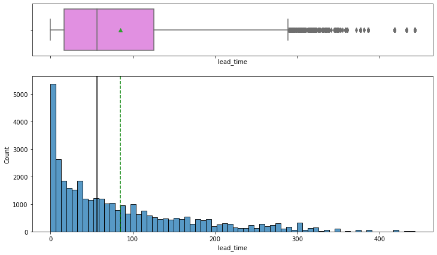

```python
histogram_boxplot(df, "lead_time")
```

```python
df["lead_time"].median()
```

```
57.0
```

Lead time has a heavy right skew with some customers booking up to a year in advance, though the median is 57.

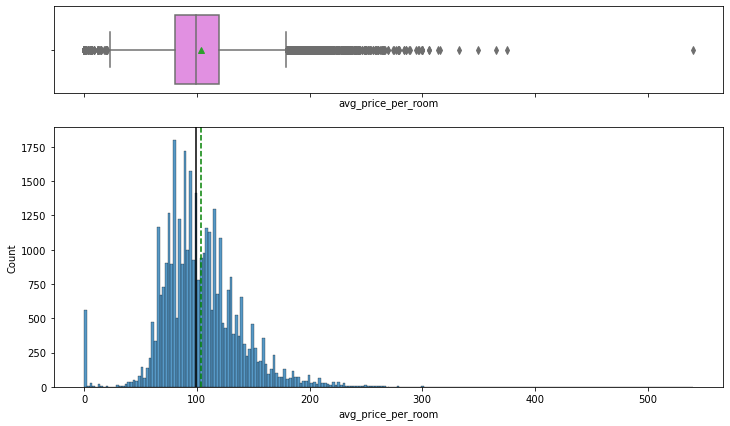

```python
histogram_boxplot(df, "avg_price_per_room")
```

The average price also has a right skew, though not as dramatic. There are around 500 entries where the price is 0, though I'm not confident that these are data entries as there could be complimentary rooms, corporate discounts, rewards offers, or something similar.

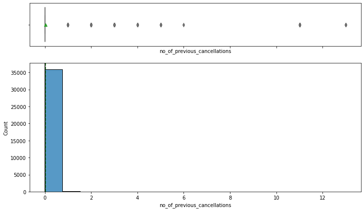

```python
histogram_boxplot(df, "no_of_previous_cancellations")
```

There are extremely few entries where the customer has previously canceled a room, so we can't learn very much from this variable.

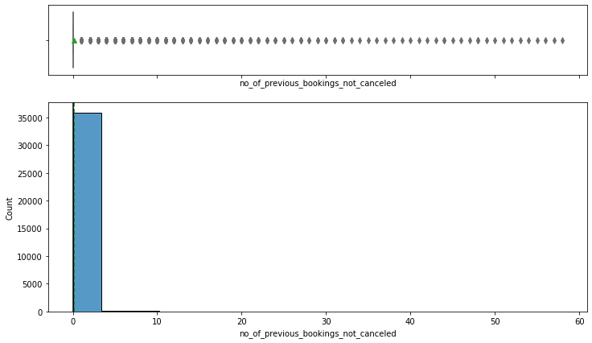

```python
histogram_boxplot(df, "no_of_previous_bookings_not_canceled")
```

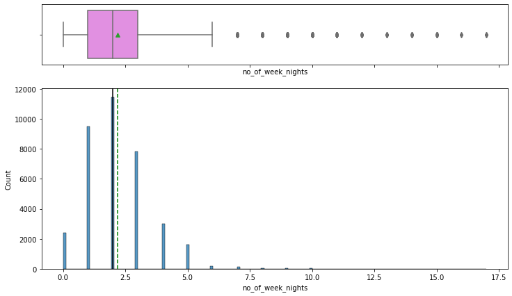

```python
histogram_boxplot(df, "no_of_week_nights")
```

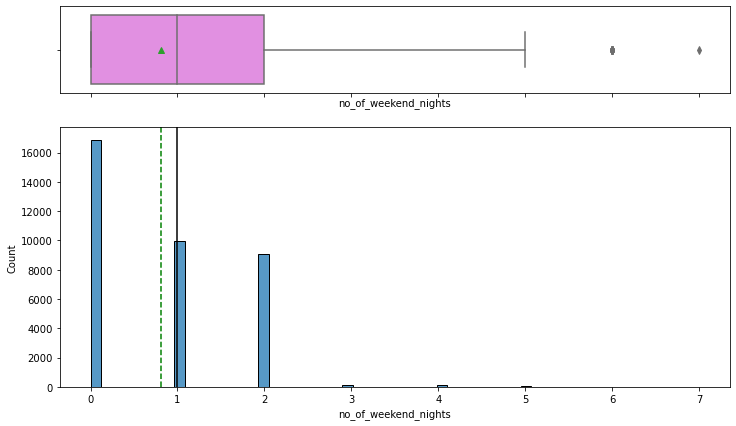

```python
histogram_boxplot(df, "no_of_weekend_nights")
```

The same holds true for previous bookings not canceled. These two variables seem to align with the repeated guest variable which shows very few repeat guests, so these variables pass a sanity test and appear to be accurate, at least in respect to each other.

```python
df = df.rename(columns = {"no_of_previous_cancellations":"cancels", "no_of_previous_bookings_not_canceled":"not_cancelled"})
```

```python
df['cancels'].value_counts()
```

```
0     35937
1       198
2        46
3        43
11       25
5        11
4        10
13        4
6         1
Name: cancels, dtype: int64
```

```python
df['not_cancelled'].value_counts().head(10)
```

```
0     35463
1       228
2       112
3        80
4        65
5        60
6        36
7        24
8        23
10       19
Name: not_cancelled, dtype: int64
```

```python
df['repeated_guest'].value_counts()
```

```
0    35345
1      930
Name: repeated_guest, dtype: int64
```

Interestingly, the very high majority of customers haven't made a reservation before. Of the 36275 entries, over 35000 have never had a cancelled reservation and over 35000 have never had an honored reservation.

```python
def labeled_barplot(data, feature, perc=False, n=None):
    """
    Barplot with percentage at the top

    data: df
    feature: column
    perc: whether to display percentages instead of count (default is False)
    n: displays the top n category levels (default is None, i.e., display all levels)
    """

    total = len(data[feature])  # length of the column
    count = data[feature].nunique()
    if n is None:
        plt.figure(figsize=(count + 1, 5))
    else:
        plt.figure(figsize=(n + 1, 5))

    plt.xticks(rotation=90, fontsize=15)
    ax = sns.countplot(
        data=data,
        x=feature,
        palette="Paired",
        order=data[feature].value_counts().index[:n].sort_values(),
    )

    for p in ax.patches:
        if perc == True:
            label = "{:.1f}%".format(
                100 * p.get_height() / total
            )  # percentage of each class of the category
        else:
            label = p.get_height()  # count of each level of the category

        x = p.get_x() + p.get_width() / 2  # width of the plot
        y = p.get_height()  # height of the plot

        ax.annotate(
            label,
            (x, y),
            ha="center",
            va="center",
            size=12,
            xytext=(0, 5),
            textcoords="offset points",
        )  # annotate the percentage

    plt.show()  # show the plot
```

```python
df_barplots = df.drop(columns = ['cancels','not_cancelled', 'lead_time', 'avg_price_per_room'], inplace=False)
```

```python
df_barplots.info()
```

```
<class 'pandas.core.frame.DataFrame'>
RangeIndex: 36275 entries, 0 to 36274
Data columns (total 14 columns):
 #   Column                      Non-Null Count  Dtype
---  ------                      --------------  -----
 0   no_of_adults                36275 non-null  int64
 1   no_of_children              36275 non-null  int64
 2   no_of_weekend_nights        36275 non-null  int64
 3   no_of_week_nights           36275 non-null  int64
 4   type_of_meal_plan           36275 non-null  object
 5   required_car_parking_space  36275 non-null  int64
 6   room_type_reserved          36275 non-null  object
 7   arrival_year                36275 non-null  int64
 8   arrival_month               36275 non-null  int64
 9   arrival_date                36275 non-null  int64
 10  market_segment_type         36275 non-null  object
 11  repeated_guest              36275 non-null  int64
 12  no_of_special_requests      36275 non-null  int64
 13  booking_status              36275 non-null  object
dtypes: int64(10), object(4)
memory usage: 3.9+ MB
```

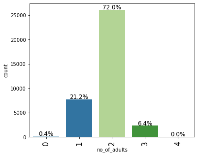

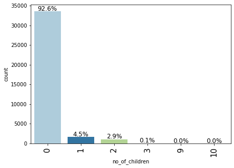

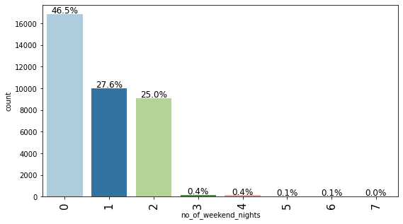

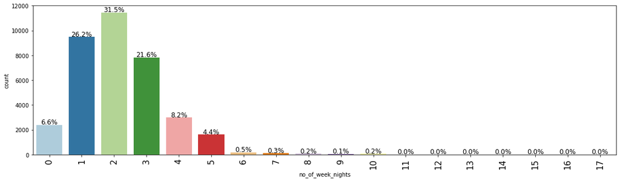

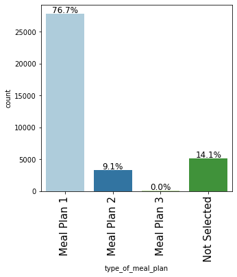

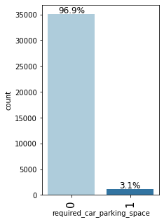

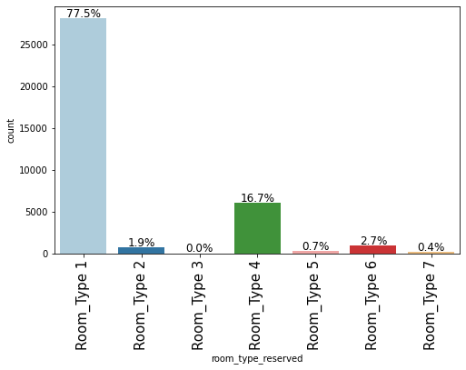

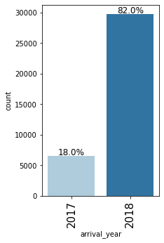

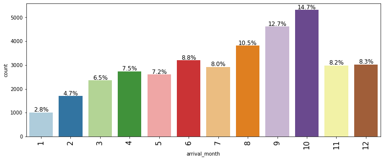

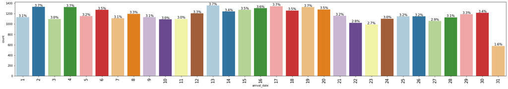

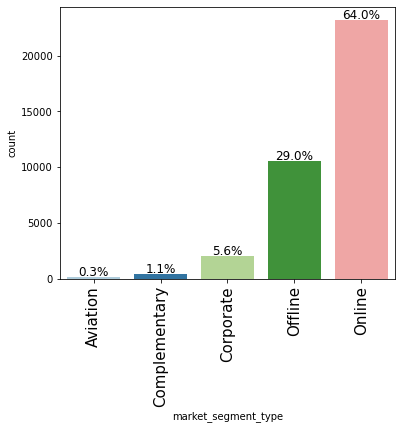

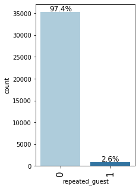

[2 more figures not shown]

```python
for i in df_barplots.columns:
    labeled_barplot(df, i, perc=True)
```

```python
df["booking_status"] = df["booking_status"].apply(
    lambda x: 1 if x == "Canceled" else 0
)
```

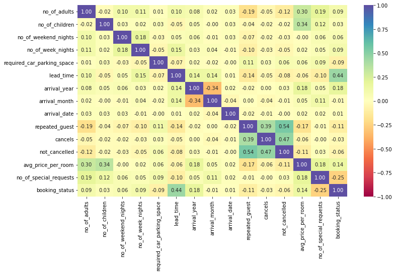

```python
cols_list = df.select_dtypes(include=np.number).columns.tolist()

plt.figure(figsize=(12, 7))
sns.heatmap(
    df[cols_list].corr(), annot=True, vmin=-1, vmax=1, fmt=".2f", cmap="Spectral"
)
plt.show()
```

At first glance, the variables most positively correlated with room cancellations are the lead time, year and average price per room. The interpretation of this is that the further in advance a room is booked, and the more it costs, the more likely it is that the reservation is cancelled. Variables like the number of occupants and number of nights are also positively correlated with a higher likelihood of cancellation, but to a lesser extent.

On the other side, the number of special requests, repeated guests and required parking spot are negatively correlated with reservation cancellations. The interpretation I take from this is that the more specifics a customer asks for (special requests, parking spot) and the more often they've visited, the less likely it is that the reservation is cancelled. An additional factor with a parking spot request is that this may imply customers who are located closer to the hotel and are driving instead of flying, which may have an impact on the likelihood of them cancelling.

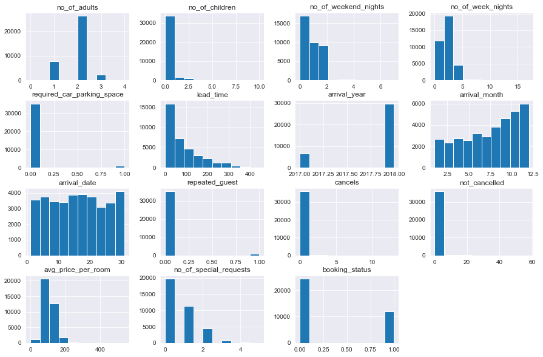

```python
sns.set_style("darkgrid")
df.hist(figsize=(15, 10))
plt.show()
```

```python
def distribution_plot_wrt_target(data, predictor, target):

    fig, axs = plt.subplots(2, 2, figsize=(12, 10))

    target_uniq = data[target].unique()

    axs[0, 0].set_title("Distribution of target for target=" + str(target_uniq[0]))
    sns.histplot(
        data=data[data[target] == target_uniq[0]],
        x=predictor,
        kde=True,
        ax=axs[0, 0],
        color="teal",
        stat="density",
    )

    axs[0, 1].set_title("Distribution of target for target=" + str(target_uniq[1]))
    sns.histplot(
        data=data[data[target] == target_uniq[1]],
        x=predictor,
        kde=True,
        ax=axs[0, 1],
        color="orange",
        stat="density",
    )

    axs[1, 0].set_title("Boxplot w.r.t target")
    sns.boxplot(data=data, x=target, y=predictor, ax=axs[1, 0], palette="gist_rainbow")

    axs[1, 1].set_title("Boxplot (without outliers) w.r.t target")
    sns.boxplot(
        data=data,
        x=target,
        y=predictor,
        ax=axs[1, 1],
        showfliers=False,
        palette="gist_rainbow",
    )

    plt.tight_layout()
    plt.show()
```

```python
def stacked_barplot(data, predictor, target):
    """
    Print the category counts and plot a stacked bar chart

    data: dataframe
    predictor: independent variable
    target: target variable
    """
    count = data[predictor].nunique()
    sorter = data[target].value_counts().index[-1]
    tab1 = pd.crosstab(data[predictor], data[target], margins=True).sort_values(
        by=sorter, ascending=False
    )
    print(tab1)
    print("-" * 120)
    tab = pd.crosstab(data[predictor], data[target], normalize="index").sort_values(
        by=sorter, ascending=False
    )
    tab.plot(kind="bar", stacked=True, figsize=(count + 5, 5))
    plt.legend(
        loc="lower left", frameon=False,
    )
    plt.legend(loc="upper left", bbox_to_anchor=(1, 1))
    plt.show()
```

## EDA Questions

What are the busiest months in the hotel?

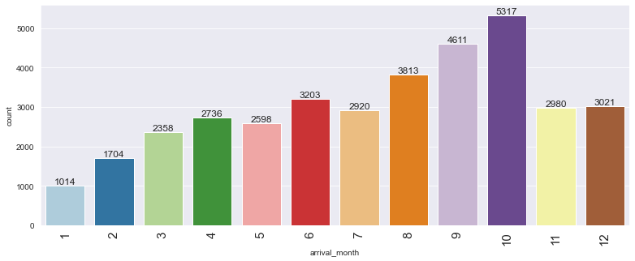

```python
labeled_barplot(df, "arrival_month")
```

Which market segment do most guests come from?

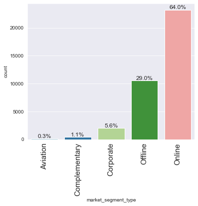

```python
labeled_barplot(df, "market_segment_type", perc=True)
```

64% of entries in our data set are from online bookings, followed by nearly a third from offline bookings. Corporate and complementary bookings also have meaningful amounts of volume.

Hotel rates are dynamic and change according to demand and customer demographics. What are the differences in room prices in different market segments?

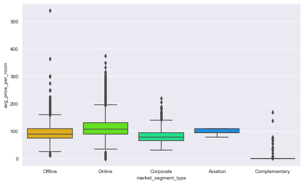

```python
plt.figure(figsize=(10, 6))
sns.boxplot(
    data=df, x="market_segment_type", y="avg_price_per_room", palette="gist_rainbow"
)
plt.show()
```

Online bookings tend to have the highest average price, while offline and corporate bookings have similar prices about 20% below online bookings on average. Unsuprisingly, the majority of complementary bookings have an average cost of 0.

What percentage of bookings are canceled?

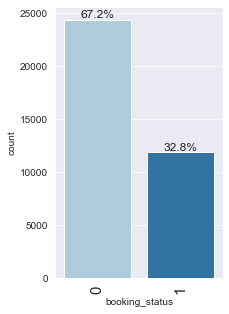

```python
labeled_barplot(df, "booking_status", perc=True)
```

About 1/3 of bookings end up being canceled.

Repeating guests are the guests who stay in the hotel often and are important to brand equity. What percentage of repeating guests cancel?

```python
df_repeat = df[df["repeated_guest"]==1]
```

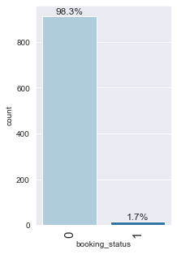

```python
labeled_barplot(df_repeat, "booking_status", perc=True)
```

Just 2% of repeated guests cancel their room, although it's important to note that this is a very small subset of the overall dataset. If this holds with larger data, repeat guests could be an important factor to consider.

Many guests have special requirements when booking a hotel room. Do these requirements affect booking cancellation?

```
booking_status              0      1    All
no_of_special_requests
All                     24390  11885  36275
0                       11232   8545  19777
1                        8670   2703  11373
2                        3727    637   4364
3                         675      0    675
4                          78      0     78
5                           8      0      8
------------------------------------------------------------------------------------------------------------------------
```

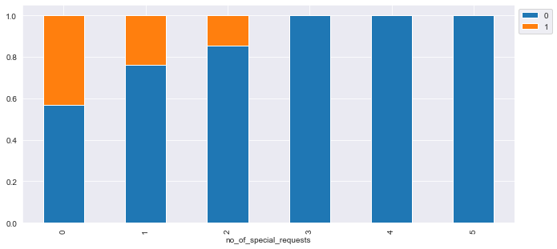

```python
stacked_barplot(df, "no_of_special_requests", "booking_status")
```

These requests seem to have a large impact on the likelihood of cancellation. While customers who have 0 special requests are over 40% likely to cancel their room, customers with 2 requests are only 15% likely, and all customers with 3 or more requests have honored their reservations.

# Data Preprocessing

- Missing value treatment (if needed)
- Feature engineering (if needed)
- Outlier detection and treatment (if needed)
- Preparing data for modeling
- Any other preprocessing steps (if needed)

## Missing Value Treatment

```python
df1 = df.copy()
```

```python
df1.isnull().sum()
```

```
no_of_adults                  0
no_of_children                0
no_of_weekend_nights          0
no_of_week_nights             0
type_of_meal_plan             0
required_car_parking_space    0
room_type_reserved            0
lead_time                     0
arrival_year                  0
arrival_month                 0
arrival_date                  0
market_segment_type           0
repeated_guest                0
cancels                       0
not_cancelled                 0
avg_price_per_room            0
no_of_special_requests        0
booking_status                0
dtype: int64
```

Missing Value Treatment Not Needed

## Outlier Detection

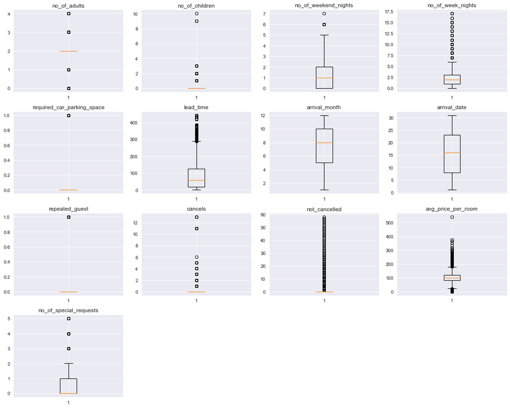

```python
# outlier detection using boxplot
numeric_columns = df1.select_dtypes(include=np.number).columns.tolist()
# dropping booking_status as it's our dependent variable
# dropping arrival_year as it is a temporal variable
numeric_columns.remove("booking_status")
numeric_columns.remove("arrival_year")

plt.figure(figsize=(15, 12))

for i, variable in enumerate(numeric_columns):
    plt.subplot(4, 4, i + 1)
    plt.boxplot(df1[variable], whis=1.5)
    plt.tight_layout()
    plt.title(variable)

plt.show()
```

I am planning to treat the outliers on the variables number of week nights, weekend nights and special requests. These three have a very small number of outliers so removing them shouldn't meaningfully impact our distribution. I will also treat the outliers on lead time and average price per room, as dropping them entirely would likely skew the data set significantly but converting them to the 1.5IQR level will help to keep our distribution tighter. I will keep all other existing outliers in the dataset, because they have either a large number of outliers, the outliers are significantly skewed in a certain direction, or they're integer variables with no boxplot distribution so an outlier test doesn't seem to make intuitive sense.

```python
def treat_outliers(df1, col):
    """
    Treats outliers in a variable
    df1: dataframe
    col: dataframe column
    """
    Q1 = df1[col].quantile(0.25)  # 25th percentile
    Q3 = df1[col].quantile(0.75)  # 75th percentile
    IQR = Q3 - Q1
    Lower_Whisker = Q1 - 1.5 * IQR
    Upper_Whisker = Q3 + 1.5 * IQR

    # all the values smaller than Lower_Whisker will be assigned the value of Lower_Whisker
    # all the values greater than Upper_Whisker will be assigned the value of Upper_Whisker
    df1[col] = np.clip(df1[col], Lower_Whisker, Upper_Whisker)

    return df1

col_list = [
    "no_of_weekend_nights",
    "no_of_week_nights",
    "no_of_special_requests",
    "lead_time",
    "avg_price_per_room"
]

def treat_outliers_all(df1, col_list):
    for c in col_list:
        df = treat_outliers(df1, c)

    return df
```

```python
df2 = treat_outliers_all(df1, col_list)
```

## Data Prep for Modeling

```python
X = df2.drop(["booking_status"], axis=1)
Y = df2["booking_status"]
```

```python
X.info()
```

```
<class 'pandas.core.frame.DataFrame'>
RangeIndex: 36275 entries, 0 to 36274
Data columns (total 17 columns):
 #   Column                      Non-Null Count  Dtype
---  ------                      --------------  -----
 0   no_of_adults                36275 non-null  int64
 1   no_of_children              36275 non-null  int64
 2   no_of_weekend_nights        36275 non-null  float64
 3   no_of_week_nights           36275 non-null  float64
 4   type_of_meal_plan           36275 non-null  object
 5   required_car_parking_space  36275 non-null  int64
 6   room_type_reserved          36275 non-null  object
 7   lead_time                   36275 non-null  float64
 8   arrival_year                36275 non-null  int64
 9   arrival_month               36275 non-null  int64
 10  arrival_date                36275 non-null  int64
 11  market_segment_type         36275 non-null  object
 12  repeated_guest              36275 non-null  int64
 13  cancels                     36275 non-null  int64
 14  not_cancelled               36275 non-null  int64
 15  avg_price_per_room          36275 non-null  float64
 16  no_of_special_requests      36275 non-null  float64
dtypes: float64(5), int64(9), object(3)
memory usage: 4.7+ MB
```

```python
X = pd.get_dummies(X,
    columns=X.select_dtypes(include=["object", "category"]).columns.tolist(),
    drop_first=True) #creating dummy variables
```

```python
X.head()
```

|  | no_of_adults | no_of_children | no_of_weekend_nights | no_of_week_nights | required_car_parking_space | lead_time | arrival_year | arrival_month | arrival_date | repeated_guest | cancels | not_cancelled | avg_price_per_room | no_of_special_requests | type_of_meal_plan_Meal Plan 2 | type_of_meal_plan_Meal Plan 3 | type_of_meal_plan_Not Selected | room_type_reserved_Room_Type 2 | room_type_reserved_Room_Type 3 | room_type_reserved_Room_Type 4 | room_type_reserved_Room_Type 5 | room_type_reserved_Room_Type 6 | room_type_reserved_Room_Type 7 | market_segment_type_Complementary | market_segment_type_Corporate | market_segment_type_Offline | market_segment_type_Online |
| --- | --- | --- | --- | --- | --- | --- | --- | --- | --- | --- | --- | --- | --- | --- | --- | --- | --- | --- | --- | --- | --- | --- | --- | --- | --- | --- | --- |
| 0 | 2 | 0 | 1.00000 | 2.00000 | 0 | 224.00000 | 2017 | 10 | 2 | 0 | 0 | 0 | 65.00000 | 0.00000 | 0 | 0 | 0 | 0 | 0 | 0 | 0 | 0 | 0 | 0 | 0 | 1 | 0 |
| 1 | 2 | 0 | 2.00000 | 3.00000 | 0 | 5.00000 | 2018 | 11 | 6 | 0 | 0 | 0 | 106.68000 | 1.00000 | 0 | 0 | 1 | 0 | 0 | 0 | 0 | 0 | 0 | 0 | 0 | 0 | 1 |
| 2 | 1 | 0 | 2.00000 | 1.00000 | 0 | 1.00000 | 2018 | 2 | 28 | 0 | 0 | 0 | 60.00000 | 0.00000 | 0 | 0 | 0 | 0 | 0 | 0 | 0 | 0 | 0 | 0 | 0 | 0 | 1 |
| 3 | 2 | 0 | 0.00000 | 2.00000 | 0 | 211.00000 | 2018 | 5 | 20 | 0 | 0 | 0 | 100.00000 | 0.00000 | 0 | 0 | 0 | 0 | 0 | 0 | 0 | 0 | 0 | 0 | 0 | 0 | 1 |
| 4 | 2 | 0 | 1.00000 | 1.00000 | 0 | 48.00000 | 2018 | 4 | 11 | 0 | 0 | 0 | 94.50000 | 0.00000 | 0 | 0 | 1 | 0 | 0 | 0 | 0 | 0 | 0 | 0 | 0 | 0 | 1 |

```python
X_train, X_test, Y_train, Y_test = train_test_split(X, Y, test_size = .3, random_state=1) # Split the data into training and testing sets
```

# EDA

- It is a good idea to explore the data once again after manipulating it.

```python
X.describe()
```

|  | no_of_adults | no_of_children | no_of_weekend_nights | no_of_week_nights | required_car_parking_space | lead_time | arrival_year | arrival_month | arrival_date | repeated_guest | cancels | not_cancelled | avg_price_per_room | no_of_special_requests | type_of_meal_plan_Meal Plan 2 | type_of_meal_plan_Meal Plan 3 | type_of_meal_plan_Not Selected | room_type_reserved_Room_Type 2 | room_type_reserved_Room_Type 3 | room_type_reserved_Room_Type 4 | room_type_reserved_Room_Type 5 | room_type_reserved_Room_Type 6 | room_type_reserved_Room_Type 7 | market_segment_type_Complementary | market_segment_type_Corporate | market_segment_type_Offline | market_segment_type_Online |
| --- | --- | --- | --- | --- | --- | --- | --- | --- | --- | --- | --- | --- | --- | --- | --- | --- | --- | --- | --- | --- | --- | --- | --- | --- | --- | --- | --- |
| count | 36275.00000 | 36275.00000 | 36275.00000 | 36275.00000 | 36275.00000 | 36275.00000 | 36275.00000 | 36275.00000 | 36275.00000 | 36275.00000 | 36275.00000 | 36275.00000 | 36275.00000 | 36275.00000 | 36275.00000 | 36275.00000 | 36275.00000 | 36275.00000 | 36275.00000 | 36275.00000 | 36275.00000 | 36275.00000 | 36275.00000 | 36275.00000 | 36275.00000 | 36275.00000 | 36275.00000 |
| mean | 1.84496 | 0.10528 | 0.81012 | 2.17784 | 0.03099 | 83.76175 | 2017.82043 | 7.42365 | 15.59700 | 0.02564 | 0.02335 | 0.15341 | 102.97018 | 0.60657 | 0.09111 | 0.00014 | 0.14142 | 0.01908 | 0.00019 | 0.16697 | 0.00731 | 0.02663 | 0.00436 | 0.01078 | 0.05560 | 0.29023 | 0.63994 |
| std | 0.51871 | 0.40265 | 0.86734 | 1.29062 | 0.17328 | 81.65691 | 0.38384 | 3.06989 | 8.74045 | 0.15805 | 0.36833 | 1.75417 | 31.68121 | 0.74695 | 0.28777 | 0.01174 | 0.34846 | 0.13680 | 0.01389 | 0.37296 | 0.08516 | 0.16100 | 0.06585 | 0.10326 | 0.22916 | 0.45387 | 0.48002 |
| min | 0.00000 | 0.00000 | 0.00000 | 0.00000 | 0.00000 | 0.00000 | 2017.00000 | 1.00000 | 1.00000 | 0.00000 | 0.00000 | 0.00000 | 20.75000 | 0.00000 | 0.00000 | 0.00000 | 0.00000 | 0.00000 | 0.00000 | 0.00000 | 0.00000 | 0.00000 | 0.00000 | 0.00000 | 0.00000 | 0.00000 | 0.00000 |
| 25% | 2.00000 | 0.00000 | 0.00000 | 1.00000 | 0.00000 | 17.00000 | 2018.00000 | 5.00000 | 8.00000 | 0.00000 | 0.00000 | 0.00000 | 80.30000 | 0.00000 | 0.00000 | 0.00000 | 0.00000 | 0.00000 | 0.00000 | 0.00000 | 0.00000 | 0.00000 | 0.00000 | 0.00000 | 0.00000 | 0.00000 | 0.00000 |
| 50% | 2.00000 | 0.00000 | 1.00000 | 2.00000 | 0.00000 | 57.00000 | 2018.00000 | 8.00000 | 16.00000 | 0.00000 | 0.00000 | 0.00000 | 99.45000 | 0.00000 | 0.00000 | 0.00000 | 0.00000 | 0.00000 | 0.00000 | 0.00000 | 0.00000 | 0.00000 | 0.00000 | 0.00000 | 0.00000 | 0.00000 | 1.00000 |
| 75% | 2.00000 | 0.00000 | 2.00000 | 3.00000 | 0.00000 | 126.00000 | 2018.00000 | 10.00000 | 23.00000 | 0.00000 | 0.00000 | 0.00000 | 120.00000 | 1.00000 | 0.00000 | 0.00000 | 0.00000 | 0.00000 | 0.00000 | 0.00000 | 0.00000 | 0.00000 | 0.00000 | 0.00000 | 0.00000 | 1.00000 | 1.00000 |
| max | 4.00000 | 10.00000 | 5.00000 | 6.00000 | 1.00000 | 289.50000 | 2018.00000 | 12.00000 | 31.00000 | 1.00000 | 13.00000 | 58.00000 | 179.55000 | 2.50000 | 1.00000 | 1.00000 | 1.00000 | 1.00000 | 1.00000 | 1.00000 | 1.00000 | 1.00000 | 1.00000 | 1.00000 | 1.00000 | 1.00000 | 1.00000 |

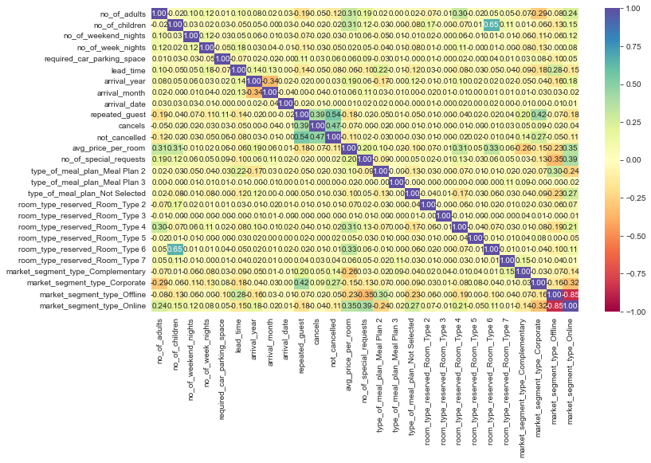

```python
cols_list = X.select_dtypes(include=np.number).columns.tolist()

plt.figure(figsize=(12, 7))
sns.heatmap(
    X[cols_list].corr(), annot=True, vmin=-1, vmax=1, fmt=".2f", cmap="Spectral"
)
plt.show()
```

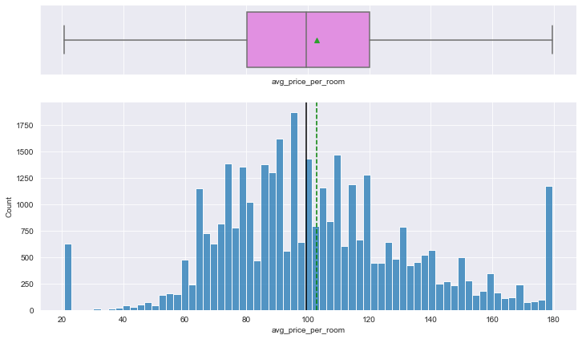

```python
histogram_boxplot(X, "avg_price_per_room")
```

Capping the outliers has made the average price much closer to a normal distribution, but with spikes at round numbers and at the high and low whiskers.

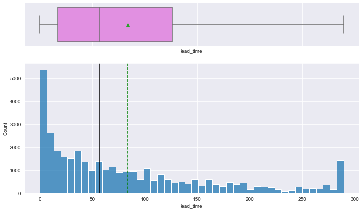

```python
histogram_boxplot(X, "lead_time")
```

Lead time still has a significant right skew, but not quite as large as before the outlier treatment due to capping the outliers at the top whisker.

# Checking Multicollinearity

- In order to make statistical inferences from a logistic regression model, it is important to ensure that there is no multicollinearity present in the data.

```python
# checking VIF of predictor variables
vif_series = pd.Series(
    [variance_inflation_factor(X_train.values, i) for i in range(X_train.shape[1])],
    index=X_train.columns,
    dtype=float,
)
print("VIF values: \n\n{}\n".format(vif_series))
```

```
VIF values:

no_of_adults                         18.39557
no_of_children                        2.10699
no_of_weekend_nights                  1.98320
no_of_week_nights                     4.20435
required_car_parking_space            1.07411
lead_time                             2.56411
arrival_year                        331.43275
arrival_month                         7.20254
arrival_date                          4.21929
repeated_guest                        1.82864
cancels                               1.40028
not_cancelled                         1.65977
avg_price_per_room                   21.41298
no_of_special_requests                2.08592
type_of_meal_plan_Meal Plan 2         1.31913
type_of_meal_plan_Meal Plan 3         1.02532
type_of_meal_plan_Not Selected        1.44463
room_type_reserved_Room_Type 2        1.12365
room_type_reserved_Room_Type 3        1.00348
room_type_reserved_Room_Type 4        1.64492
room_type_reserved_Room_Type 5        1.03534
room_type_reserved_Room_Type 6        1.97934
room_type_reserved_Room_Type 7        1.09877
market_segment_type_Complementary     4.49258
market_segment_type_Corporate        17.87924
market_segment_type_Offline          89.89390
market_segment_type_Online          198.26104
dtype: float64
```

There are a handful of variables with very high vif values. I'll remove them from the dataset one at a time to see how that impacts the others.

```python
cols = X_train.columns.tolist()

# setting an initial max p-value
# max_VIF_value = 500

while len(cols) > 0:
    # defining the train set
    X_train_aux = X_train[cols]

    # get vif values and max vif value

    vif_series = pd.Series(
    [variance_inflation_factor(X_train_aux.values, i) for i in range(X_train_aux.shape[1])],
    index=X_train_aux.columns,
    dtype=float)

    max_vif_value = max(vif_series)

    # name of the variable with maximum p-value
    feature_with_vif_max = vif_series.idxmax()

    if max_vif_value > 10:
        cols.remove(feature_with_vif_max)
    else:
        break

selected_features = cols
print(selected_features)
```

[output not shown]

```python
vif_series = pd.Series(
    [variance_inflation_factor(X_train_aux.values, i) for i in range(X_train_aux.shape[1])],
    index=X_train_aux.columns,
    dtype=float,
)
print("VIF values: \n\n{}\n".format(vif_series))
```

```
VIF values:

no_of_children                      2.06934
no_of_weekend_nights                1.89597
no_of_week_nights                   3.81115
required_car_parking_space          1.07351
lead_time                           2.48027
arrival_month                       6.51779
arrival_date                        3.82611
repeated_guest                      1.81426
cancels                             1.39731
not_cancelled                       1.65848
avg_price_per_room                  9.67464
no_of_special_requests              2.03565
type_of_meal_plan_Meal Plan 2       1.29544
type_of_meal_plan_Meal Plan 3       1.02526
type_of_meal_plan_Not Selected      1.32209
room_type_reserved_Room_Type 2      1.10837
room_type_reserved_Room_Type 3      1.00341
room_type_reserved_Room_Type 4      1.54801
room_type_reserved_Room_Type 5      1.02998
room_type_reserved_Room_Type 6      1.92312
room_type_reserved_Room_Type 7      1.08516
market_segment_type_Complementary   1.16102
market_segment_type_Corporate       1.45388
market_segment_type_Offline         1.93828
dtype: float64
```

I've successfully removed all variables with vif values above 10, using a loop to do that process one at a time. This allowed me to keep variables like average price per room, which had an initial vif value greater than 10 but decreased as we removed high vif value variables.

```python
# initial list of columns
cols = X_train_aux.columns.tolist()

# setting an initial max p-value
max_p_value = 1

while len(cols) > 0:
    # defining the train set
    X_train_aux1 = X_train_aux[cols]

    # fitting the model
    model = sm.Logit(Y_train, X_train_aux1).fit(disp=False)

    # getting the p-values and the maximum p-value
    p_values = model.pvalues
    max_p_value = max(p_values)

    # name of the variable with maximum p-value
    feature_with_p_max = p_values.idxmax()

    if max_p_value > 0.05:
        cols.remove(feature_with_p_max)
    else:
        break

selected_features = cols
print(selected_features)
```

[output not shown]

```python
vif_series = pd.Series(
    [variance_inflation_factor(X_train_aux1.values, i) for i in range(X_train_aux1.shape[1])],
    index=X_train_aux1.columns,
    dtype=float,
)
print("VIF values: \n\n{}\n".format(vif_series))
```

```
VIF values:

no_of_children                   1.20466
no_of_week_nights                3.69331
required_car_parking_space       1.07228
lead_time                        2.44120
arrival_month                    6.14633
arrival_date                     3.69764
repeated_guest                   1.52769
cancels                          1.20715
avg_price_per_room               7.91904
no_of_special_requests           2.01193
type_of_meal_plan_Meal Plan 2    1.27632
room_type_reserved_Room_Type 2   1.06541
market_segment_type_Corporate    1.37164
market_segment_type_Offline      1.81256
dtype: float64
```

Running a loop to remove variables with high p-values has allowed us to further trim down the list of independent variables.

```python
X_train1 = X_train_aux1
X_test1 = X_test[selected_features]
```

```python
X_train1.info()
```

```
<class 'pandas.core.frame.DataFrame'>
Int64Index: 25392 entries, 13662 to 33003
Data columns (total 14 columns):
 #   Column                          Non-Null Count  Dtype
---  ------                          --------------  -----
 0   no_of_children                  25392 non-null  int64
 1   no_of_week_nights               25392 non-null  float64
 2   required_car_parking_space      25392 non-null  int64
 3   lead_time                       25392 non-null  float64
 4   arrival_month                   25392 non-null  int64
 5   arrival_date                    25392 non-null  int64
 6   repeated_guest                  25392 non-null  int64
 7   cancels                         25392 non-null  int64
 8   avg_price_per_room              25392 non-null  float64
 9   no_of_special_requests          25392 non-null  float64
 10  type_of_meal_plan_Meal Plan 2   25392 non-null  uint8
 11  room_type_reserved_Room_Type 2  25392 non-null  uint8
 12  market_segment_type_Corporate   25392 non-null  uint8
 13  market_segment_type_Offline     25392 non-null  uint8
dtypes: float64(4), int64(6), uint8(4)
memory usage: 2.2 MB
```

```python
X_test1.info()
```

```
<class 'pandas.core.frame.DataFrame'>
Int64Index: 10883 entries, 30392 to 9399
Data columns (total 14 columns):
 #   Column                          Non-Null Count  Dtype
---  ------                          --------------  -----
 0   no_of_children                  10883 non-null  int64
 1   no_of_week_nights               10883 non-null  float64
 2   required_car_parking_space      10883 non-null  int64
 3   lead_time                       10883 non-null  float64
 4   arrival_month                   10883 non-null  int64
 5   arrival_date                    10883 non-null  int64
 6   repeated_guest                  10883 non-null  int64
 7   cancels                         10883 non-null  int64
 8   avg_price_per_room              10883 non-null  float64
 9   no_of_special_requests          10883 non-null  float64
 10  type_of_meal_plan_Meal Plan 2   10883 non-null  uint8
 11  room_type_reserved_Room_Type 2  10883 non-null  uint8
 12  market_segment_type_Corporate   10883 non-null  uint8
 13  market_segment_type_Offline     10883 non-null  uint8
dtypes: float64(4), int64(6), uint8(4)
memory usage: 977.8 KB
```

# Building a Logistic Regression model

```python
logit = sm.Logit(Y_train, X_train1.astype(float))
lg = logit.fit()
```

```
Optimization terminated successfully.
         Current function value: 0.445394
         Iterations 9
```

```python
print(lg.summary())
```

```
                           Logit Regression Results
==============================================================================
Dep. Variable:         booking_status   No. Observations:                25392
Model:                          Logit   Df Residuals:                    25378
Method:                           MLE   Df Model:                           13
Date:                Fri, 25 Mar 2022   Pseudo R-squ.:                  0.2972
Time:                        20:27:31   Log-Likelihood:                -11309.
converged:                       True   LL-Null:                       -16091.
Covariance Type:            nonrobust   LLR p-value:                     0.000
==================================================================================================
                                     coef    std err          z      P>|z|      [0.025      0.975]
--------------------------------------------------------------------------------------------------
no_of_children                     0.2181      0.042      5.242      0.000       0.137       0.300
no_of_week_nights                 -0.1076      0.012     -8.649      0.000      -0.132      -0.083
required_car_parking_space        -1.5905      0.136    -11.733      0.000      -1.856      -1.325
lead_time                          0.0160      0.000     63.108      0.000       0.016       0.017
arrival_month                     -0.1103      0.005    -20.555      0.000      -0.121      -0.100
arrival_date                      -0.0173      0.002     -9.759      0.000      -0.021      -0.014
repeated_guest                    -3.0665      0.512     -5.987      0.000      -4.070      -2.063
cancels                            0.1823      0.073      2.487      0.013       0.039       0.326
avg_price_per_room                 0.0061      0.000     14.116      0.000       0.005       0.007
no_of_special_requests            -1.4782      0.029    -50.868      0.000      -1.535      -1.421
type_of_meal_plan_Meal Plan 2      0.3734      0.060      6.180      0.000       0.255       0.492
room_type_reserved_Room_Type 2    -0.7761      0.123     -6.293      0.000      -1.018      -0.534
market_segment_type_Corporate     -1.4593      0.096    -15.186      0.000      -1.648      -1.271
market_segment_type_Offline       -2.2216      0.048    -46.614      0.000      -2.315      -2.128
==================================================================================================
```

# Model performance evaluation

```python
pred_train = lg.predict(X_train1) > 0.5
pred_train = np.round(pred_train)
```

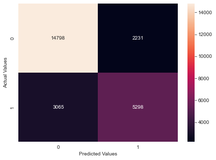

```python
cm = confusion_matrix(Y_train, pred_train)
plt.figure(figsize=(7, 5))
sns.heatmap(cm, annot=True, fmt="g")
plt.xlabel("Predicted Values")
plt.ylabel("Actual Values")
plt.show()
```

## Accuracy Check

```python
print("Accuracy on training set : ", accuracy_score(Y_train, pred_train))
```

```
Accuracy on training set :  0.7914303717706365
```

```python
def model_performance_classification_statsmodels(
    model, predictors, target, threshold=0.5
):
    """
    Function to compute different metrics to check classification model performance

    model: classifier
    predictors: independent variables
    target: dependent variable
    threshold: threshold for classifying the observation as class 1
    """

    # checking which probabilities are greater than threshold
    pred_temp = model.predict(predictors) > threshold
    # rounding off the above values to get classes
    pred = np.round(pred_temp)

    acc = accuracy_score(target, pred)  # to compute Accuracy
    recall = recall_score(target, pred)  # to compute Recall
    precision = precision_score(target, pred)  # to compute Precision
    f1 = f1_score(target, pred)  # to compute F1-score

    # creating a dataframe of metrics
    df_perf = pd.DataFrame(
        {"Accuracy": acc, "Recall": recall, "Precision": precision, "F1": f1,},
        index=[0],
    )

    return df_perf
```

```python
print("Training performance:")
log_reg_model_train_perf = model_performance_classification_statsmodels(lg, X_train1, Y_train) ## Complete the code to check performance on X_train1 and y_train
log_reg_model_train_perf
```

```
Training performance:
```

|  | Accuracy | Recall | Precision | F1 |
| --- | --- | --- | --- | --- |
| 0 | 0.79143 | 0.63350 | 0.70368 | 0.66675 |